# Определение возраста покупателей

Сетевой супермаркет внедряет систему компьютерного зрения для обработки фотографий покупателей. Фотофиксация в прикассовой зоне поможет определять возраст клиентов, чтобы:

- анализировать покупки и предлагать товары, которые могут заинтересовать покупателей этой возрастной группы;
- контролировать добросовестность кассиров при продаже алкоголя.

*Цель:* построить модель, которая по фотографии определит приблизительный возраст человека.

*Исходные данные*: в нашем распоряжении набор фотографий людей, а также файл с указанием возраста человека на фотографии - данные взяты с сайта ChaLearn Looking at People.

*Этапы выполнения проекта:*

1. Исследовательский анализ набора данных.
2. Обучение модели.
3. Анализ результата обучения модели.

```python
#импорт библиотек
import pandas as pd
import numpy as np
import matplotlib.pyplot as plt

from PIL import Image
from tensorflow.keras.preprocessing.image import ImageDataGenerator
```

## Исследовательский анализ данных

Исследовательский анализ данных проведем по следующим этапам:

- определение размера выборки,
- график распределения возраста в выборке,
- печать 10 фотографий,
- выводы о влиянии результатов исследования на обучение модели.

```python
# целевой признак
labels = pd.read_csv('/datasets/faces/labels.csv')
labels.info()
```

```
<class 'pandas.core.frame.DataFrame'>
RangeIndex: 7591 entries, 0 to 7590
Data columns (total 2 columns):
 #   Column     Non-Null Count  Dtype
---  ------     --------------  -----
 0   file_name  7591 non-null   object
 1   real_age   7591 non-null   int64
dtypes: int64(1), object(1)
memory usage: 118.7+ KB
```

Выборка состоит из 7591 размеченного изображения без пропусков. Посмотрим на распределение целевого признака:

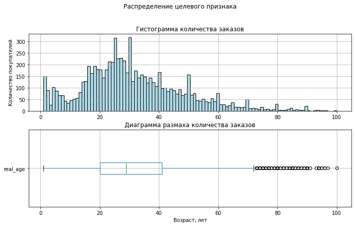

```python
plt.figure(figsize=(10,6))
plt.suptitle("Распределение целевого признака")

plt.subplot(2, 1, 1)
plt.title("Гистограмма количества заказов")
labels['real_age'].hist(bins=100, edgecolor = "black", color = "lightblue")
plt.ylabel('Количество покупателей')
plt.tight_layout(2)
plt.subplot(2, 1, 2)
plt.title("Диаграмма размаха количества заказов")
labels.boxplot(vert=False)
plt.xlabel("Возраст, лет");
```

```python
#статистическое описание данных:
labels.describe()
```

|  | real_age |
| --- | --- |
| count | 7591.000000 |
| mean | 31.201159 |
| std | 17.145060 |
| min | 1.000000 |
| 25% | 20.000000 |
| 50% | 29.000000 |
| 75% | 41.000000 |
| max | 100.000000 |

Возраст людей на фотографиях варьируется от 1 года до 100 лет, большинство фотографий при этом принадлежит людям от 15 до 45 лет. Средний возраст составляет 29-31 год. Представители возраста старше 70 лет редки и малочислены.

Посмотрим на изображения:

```python
#выберем случайные 10 изображений:
labels_sample = labels.sample(10)
labels_sample
```

|  | file_name | real_age |
| --- | --- | --- |
| 4969 | 004969.jpg | 27 |
| 4475 | 004475.jpg | 5 |
| 1897 | 001897.jpg | 16 |
| 2602 | 002602.jpg | 34 |
| 2092 | 002092.jpg | 25 |
| 3198 | 003198.jpg | 28 |
| 1656 | 001656.jpg | 41 |
| 4411 | 004411.jpg | 66 |
| 3203 | 003203.jpg | 29 |
| 4374 | 004374.jpg | 1 |

```
file_name    004969.jpg
real_age             27
Name: 4969, dtype: object
```

[figure not shown]

```
Размер изображения:  (509, 510, 3)

file_name    004475.jpg
real_age              5
Name: 4475, dtype: object
```

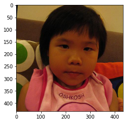

```
Размер изображения:  (434, 434, 3)

file_name    001897.jpg
real_age             16
Name: 1897, dtype: object
```

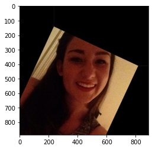

```
Размер изображения:  (887, 887, 3)

file_name    002602.jpg
real_age             34
Name: 2602, dtype: object
```

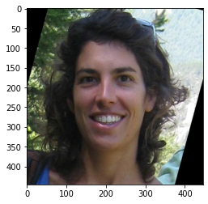

```
Размер изображения:  (446, 446, 3)

file_name    002092.jpg
real_age             25
Name: 2092, dtype: object
```

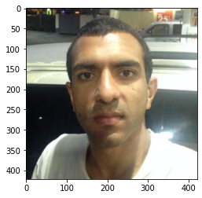

```
Размер изображения:  (422, 422, 3)

file_name    003198.jpg
real_age             28
Name: 3198, dtype: object
```

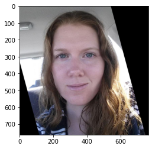

```
Размер изображения:  (764, 764, 3)

file_name    001656.jpg
real_age             41
Name: 1656, dtype: object
```

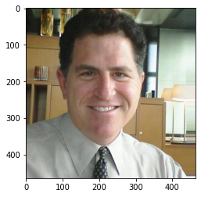

```
Размер изображения:  (465, 464, 3)

file_name    004411.jpg
real_age             66
Name: 4411, dtype: object
```

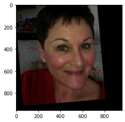

```
Размер изображения:  (956, 956, 3)

file_name    003203.jpg
real_age             29
Name: 3203, dtype: object
```

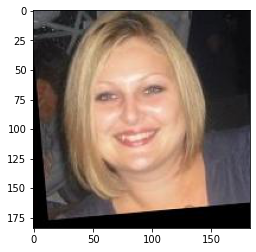

```
Размер изображения:  (184, 183, 3)

file_name    004374.jpg
real_age              1
Name: 4374, dtype: object
```

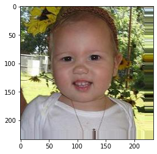

```
Размер изображения:  (234, 234, 3)
```

```python
for i in labels_sample.index:
    print (labels_sample.loc[i])
    image = Image.open('/datasets/faces/final_files/' + str(labels_sample.loc[i, 'file_name']))
    image_array = np.array(image)
    plt.imshow(image_array)
    plt.show()
    print('Размер изображения: ', image_array.shape)
    print()
```

*Вывод:* выборка достаточно большая, чтобы избежать переобучения при использовании таких моделей, как ResNet50 без заморозки слоев. В изображениях присутствуют шумы и повороты изображений. Большинство изображений при этом принадлежит людям от 15 до 45 лет, в связи с чем покупатели других возрастов могут хуже идентифицироваться моделью.

## Обучение модели

Для определения возраста по фотографии человека обучена модель ResNet50.

*Код обучения модели (свёрточная нейронная сеть):*

```
from tensorflow.keras import Sequential
from tensorflow.keras.layers import Conv2D, Flatten, Dense, AvgPool2D, MaxPool2D, GlobalAveragePooling2D
import matplotlib.pyplot as plt
import numpy as np
import pandas as pd
from tensorflow.keras.preprocessing.image import ImageDataGenerator
from tensorflow.keras.optimizers import Adam
from tensorflow.keras.applications.resnet import ResNet50


def load_train(path):
    labels = pd.read_csv(f'{path}/labels.csv')
    train_datagen = ImageDataGenerator(validation_split=0.25, rescale=1/255.,
                                       horizontal_flip=True,
                                       width_shift_range=0.2,
                                       height_shift_range=0.2)
    train_datagen_flow = train_datagen.flow_from_dataframe(dataframe = labels,
                                                           directory=f'{path}/final_files',
                                                           x_col='file_name',
                                                           y_col='real_age',
                                                           target_size=(224, 224), batch_size=32, class_mode='raw',
                                                           subset='training',
                                                           seed=12345)
    return train_datagen_flow

def load_test(path):
    labels = pd.read_csv(f'{path}/labels.csv')
    validation_datagen = ImageDataGenerator(validation_split=0.25, rescale=1/255)
    val_datagen_flow = validation_datagen.flow_from_dataframe(dataframe = labels,
                                                              directory = f'{path}/final_files',
                                                              x_col='file_name',
                                                              y_col='real_age',
                                                              target_size=(224, 224), batch_size=32, class_mode='raw',
                                                              subset='validation', seed=12345)
    return val_datagen_flow

def create_model(input_shape):
    backbone = ResNet50(input_shape=input_shape,
                    weights='/datasets/keras_models/resnet50_weights_tf_dim_ordering_tf_kernels_notop.h5',
                    include_top=False)
    model = Sequential()
    optimizer = Adam(lr=0.0001)
    model.add(backbone)
    model.add(GlobalAveragePooling2D())
    model.add(Flatten())
    model.add(Dense(1, activation='relu'))
    model.compile(optimizer=optimizer, loss='mse',
                  metrics=['mae'])
    return model

def train_model(model, train_data, test_data, batch_size=None, epochs=5,
               steps_per_epoch=None, validation_steps=None):
    model.fit(train_data,
              validation_data=test_data,
              batch_size=batch_size, epochs=epochs,
              steps_per_epoch=steps_per_epoch,
              validation_steps=validation_steps,
              verbose=2)
    return model
```

*Результат вывода модели:*

```
Found 5694 validated image filenames.
Found 1897 validated image filenames.

Train for 178 steps, validate for 60 steps
Epoch 1/5
178/178 - 118s - loss: 240.8426 - mae: 11.1790 - val_loss: 817.6737 - val_mae: 23.6966
Epoch 2/5
178/178 - 109s - loss: 93.7813 - mae: 7.3402 - val_loss: 801.7357 - val_mae: 23.3465
Epoch 3/5
178/178 - 108s - loss: 70.9050 - mae: 6.3739 - val_loss: 405.6378 - val_mae: 15.0426
Epoch 4/5
178/178 - 109s - loss: 57.7064 - mae: 5.7750 - val_loss: 137.7152 - val_mae: 8.7180
Epoch 5/5
178/178 - 109s - loss: 47.3575 - mae: 5.2871 - val_loss: 84.4728 - val_mae: 6.7557

60/60 - 11s - loss: 84.4728 - mae: 6.7557
```

*Вывод*: достигнута метрика качества - средняя абсолютная ошибка - равная 6.76.

## Анализ обученной модели

Для обучения модели для определения возраста человека по его фотографии были использованы размеченные данные - 7591 фотография с определенным целевым признаком `возраст`, которые были поделены в пропорции 3:1 на тренировочную и валидационные выборки.

На тренировочной выборке проведено обучение сверточной нейронной сети ResNet50 с использованием архитектуры костяка ResNet50 + верхний слой, соответствующий поставленной задаче (определение возраста), и инициализацией предобученных весов 'imagenet'. В модели также использован алгоритм оптимизации Adam с параметром скорости обучения = 0.0001. Обучение проводилось на батчах размером 32 в 5 эпохах без заморозки слоев костяка ResNet50.

В результате обучения модели достигнут целевой показатель качества модели на валидационной выборке (средняя абсолютная ошибка), равный 6.76, т.е. в среднем при определении возраста модель ошибается на 7 лет. В первых двух эпохах наблюдалось переобучение модели, которое скооректировалолсь к 5 эпохе, на которой разница целевых метрик на тренировочной и валидационной выборках составила менее 2.